# Cognition

[back to Home page |](https://github.com/huiwen-goy/C2-multidomain) [back to Analyses page |](https://huiwen-goy.github.io/C2-multidomain/C2-11Analyses.html) [Data quality |](https://huiwen-goy.github.io/C2-multidomain/C2-1Quality.html)

[Demographics |](https://huiwen-goy.github.io/C2-multidomain/C2-2Demographic.html) [Physical health |](https://huiwen-goy.github.io/C2-multidomain/C2-3Physical.html) [Hearing |](https://huiwen-goy.github.io/C2-multidomain/C2-4Hearing.html) [Cognition |](https://huiwen-goy.github.io/C2-multidomain/C2-5Cognition.html) [Mobility and balance |](https://huiwen-goy.github.io/C2-multidomain/C2-6Mobility.html) [Quality of life |](https://huiwen-goy.github.io/C2-multidomain/C2-7QoL.html) [Mental health |](https://huiwen-goy.github.io/C2-multidomain/C2-8Mental.html) [Social |](https://huiwen-goy.github.io/C2-multidomain/C2-9Social.html) [Views |](https://huiwen-goy.github.io/C2-multidomain/C2-10Views.html)

# Subjective cognitive impairment

Response options are “Yes” or “No” only.  
Q1 is “Do you feel like our memory or thinking is becoming worse?”  
Only people who said “Yes” to Q1 were presented with Q2: “Does this worry you?”  
Q3 was presented to all participants: “Do you feel like your memory or thinking is worse than that of other people the same age as you?”  
59 participants responded “Yes” to all three questions and are flagged as “Subjective Cognitive Impairment” in the scatterplot below.  
Source: CLSA (main wave v4.0 June 2018).

```
##   Memory/thinking becoming worse    %
## 1                            Yes 44.4
## 2                             No 52.8
## 3                           <NA>  2.8
```

```
##   If becoming worse, worries you    %
## 1                            Yes 70.1
## 2                             No 29.9
## 3                           <NA>  0.0
```

```
##   Memory/thinking worse than peers    %
## 1                              Yes 12.7
## 2                               No 84.4
## 3                             <NA>  2.8
```

# Cognitive Self-Report Questionnaire

back to top

Responses are discrete options, ranging from 1 (Almost Always) to 5 (Hardly Ever), to questions such as “I have felt I have a good memory.”. There is a valid option of “Does not apply to me”. The overall score is an average of responses, with lower numbers indicating fewer cognitive problems. 13 items are reverse-coded.

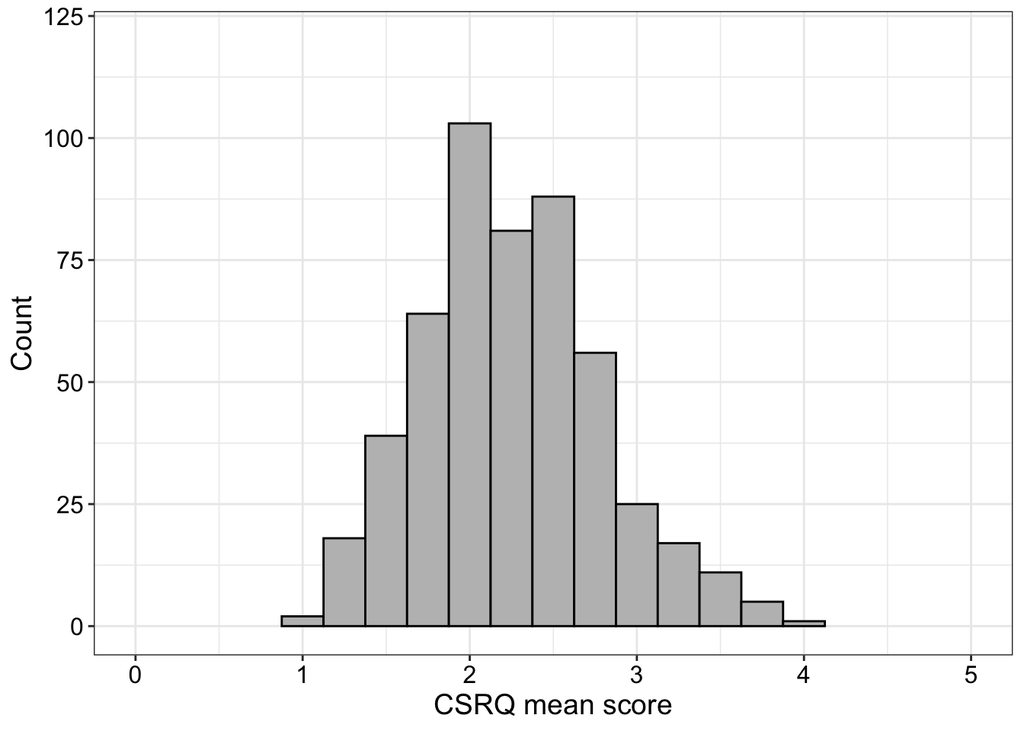

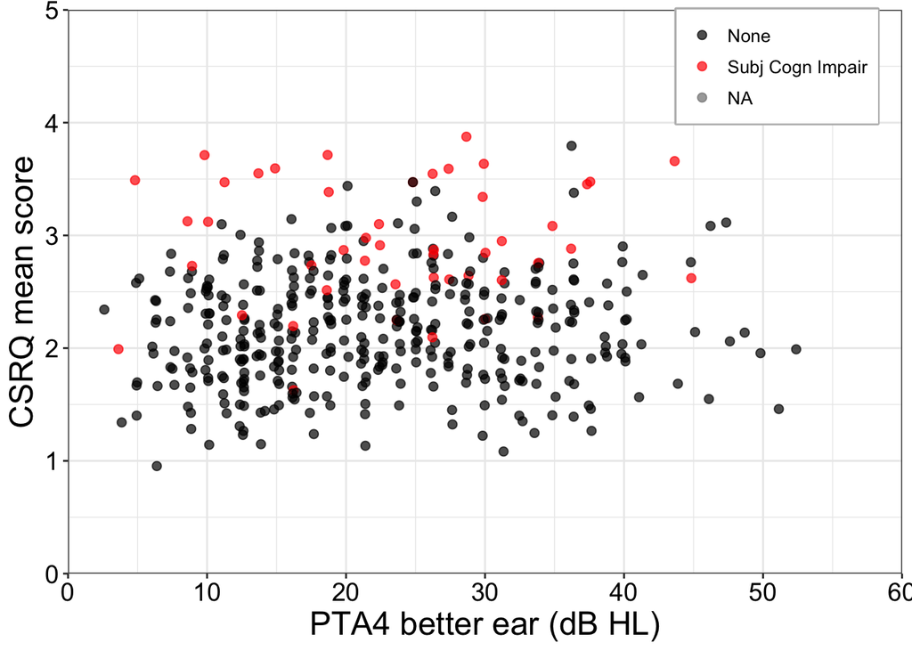

# Other variables available

back to top

- Subsets of other questionnaires, e.g. WHOQOL-BREF’s “How well are you able to concentrate?”